# Churn Prediction Modeling

#### Submitted By:J Krishna Ravali(19MBMB12)

### Installing necessary libraries

```python
# Artificial Neural Network

# Installing Theano
# pip install --upgrade --no-deps git+git://github.com/Theano/Theano.git

# Installing Tensorflow
# Install Tensorflow from the website: https://www.tensorflow.org/versions/r0.12/get_started/os_setup.html

# Installing Keras
#!pip install --upgrade keras
```

### Importing the libraries

```python
#import matplotlib.pyplot as plt
import pandas as pd
from IPython.core.interactiveshell import InteractiveShell
InteractiveShell.ast_node_interactivity = "all"
%matplotlib inline
import numpy as np
# fix random seed for reproducibility
seed = 42
np.random.seed(seed)
```

### Importing the dataset

```python
# Importing the dataset
dataset = pd.read_csv('C:/users/krish/Downloads/Churn_Modelling.csv')
#checking data shape and describing the dataset
dataset.shape
dataset.describe
```

```
(10000, 14)
```

```
<bound method NDFrame.describe of       RowNumber  CustomerId    Surname  CreditScore Geography  Gender  Age  \
0             1    15634602   Hargrave          619    France  Female   42
1             2    15647311       Hill          608     Spain  Female   41
2             3    15619304       Onio          502    France  Female   42
3             4    15701354       Boni          699    France  Female   39
4             5    15737888   Mitchell          850     Spain  Female   43
...         ...         ...        ...          ...       ...     ...  ...
9995       9996    15606229   Obijiaku          771    France    Male   39
9996       9997    15569892  Johnstone          516    France    Male   35
9997       9998    15584532        Liu          709    France  Female   36
9998       9999    15682355  Sabbatini          772   Germany    Male   42
9999      10000    15628319     Walker          792    France  Female   28

      Tenure    Balance  NumOfProducts  HasCrCard  IsActiveMember  \
0          2       0.00              1          1               1
```

[output cut: 25 more lines]

### Exploratory Data Analysis

#### Using klib library for EDA

```python
import klib
klib.missingval_plot(dataset)
```

```
No missing values found in the dataset.
```

### Feature Engineering

```python
#pre-processing the dataset
dataset = dataset.drop(['RowNumber', 'CustomerId', 'Surname'], axis=1)
```

```python
# Encoding categorical data
# Get one hot encoding of columns B
one_hot_geo = pd.get_dummies(dataset['Geography'])


# Drop column B as it is now encoded
dataset = dataset.drop('Geography',axis = 1)

# Join the encoded df
dataset= dataset.join(one_hot_geo)


# Get one hot encoding of columns B
one_hot_gen = pd.get_dummies(dataset['Gender'])
# Drop column B as it is now encoded
dataset = dataset.drop('Gender',axis = 1)
# Join the encoded df
dataset= dataset.join(one_hot_gen)
```

#### Correlation plot

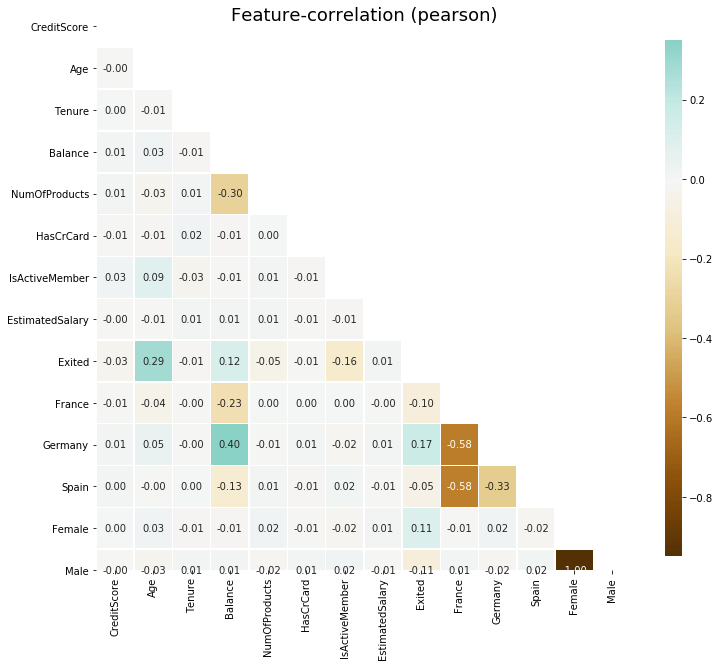

```python
klib.corr_plot(dataset)
```

### Seperating input and target fields followed by train and test split

```python
X = dataset.iloc[:, [0,1,2,3,4,5,6,7,9,10,11,12,13]].values
y = dataset.iloc[:, 8].values


# Splitting the dataset into the Training set and Test set
from sklearn.model_selection import train_test_split
X_train, X_test, y_train, y_test = train_test_split(X, y, test_size = 0.2, random_state = 0)
```

```python
# Part 2 - Now let's make the ANN!

# Importing the Keras libraries and packages
#pip install tensorflow
import tensorflow
from tensorflow.keras import Sequential
from tensorflow.keras.layers import Dense

print(tensorflow.__version__)
```

```
2.2.0
```

```python
# determine the number of input features
n_features = X_train.shape[1]
```

### Baseline model (6,8,1) epoch=100

```python
# define model
model = Sequential()
#hidden layer 1 with 6 perceptrons with relu as activation function as relu
#(rectified linear activation function or ReLU for short is a piecewise linear function that will output the input directly if it is positive, otherwise, it will output zero)
#kernel_intializer is parameter to choose intial weights with which neural network starts to optimize cost function
#he_normal: It draws samples from a truncated normal distribution centered on 0 with stddev = sqrt(2 / fan_in) where fan_in is the number of input units in the weight tensor.

model.add(Dense(6, activation='relu', kernel_initializer='he_normal', input_shape=(n_features,)))
#hidden layer 2 with 8 perceptrons
model.add(Dense(8, activation='relu', kernel_initializer='he_normal'))
#this is output layer giving single output, since the problem is binary classification of checking if a customer churns or not
#so we used sigmoid activation function which is the logic behind logistic function which outputs either 1 or 0 depending on threshold value
model.add(Dense(1, activation='sigmoid'))
```

```python
# compile the model

#Compile defines the loss function, the optimizer and the metrics. a model needs to be compiled to train using the defined loss and optimizer

#here optimizer is a technique using which model tries to arrive at final weights by adjusting the loss function values

#loss is the quantitized value of deviation from the expected performance, here binary cross entropy is used as loss function which is a cross entropy in combination with sigmoid.
#it is independent for each vector component (class), meaning that the loss computed for every CNN output vector component is not affected by other component values

#here accuracy is considered as metric to evaluate model performance

model.compile(optimizer='adam', loss='binary_crossentropy', metrics=['accuracy'])
```

```python
# fit the model
model.fit(X_train, y_train, epochs=100, batch_size=32, verbose=0)
```

```
<tensorflow.python.keras.callbacks.History at 0x2596860c5c8>
```

```python
# evaluate the model
loss, acc = model.evaluate(X_test, y_test, verbose=0)
print('Test Accuracy: %.3f' % acc)
```

```
Test Accuracy: 0.798
```

```python
# make a prediction
#['CreditScore', 'Age', 'Tenure', 'Balance', 'NumOfProducts', 'HasCrCard','IsActiveMember', 'EstimatedSalary',
#'France', 'Germany','Spain', 'Female', 'Male']
new_data = [5.9700000e+02, 3.5000000e+01, 8.0000000e+00, 1.3110104e+05,
       1.0000000e+00, 1.0000000e+00, 1.0000000e+00, 1.9285267e+05,
       0.0000000e+00, 1.0000000e+00, 0.0000000e+00, 1.0000000e+00,
       0.0000000e+00]
yhat = model.predict([new_data])
print('Predicted: %.3f' % yhat)
```

```
Predicted: 0.204
```

```python
score =model.evaluate(X_test, y_test, batch_size=10)
print('Test loss:', score[0])   #13.7581
print('Test accuracy:', score[1])   # 0.7919
```

```
Test loss: 0.5039157271385193
Test accuracy: 0.7975000143051147
```

```python
# Predicting the Test set results
y_pred = model.predict(X_test)
y_pred = (y_pred > 0.5)

# Making the Confusion Matrix
from sklearn.metrics import confusion_matrix
cm = confusion_matrix(y_test, y_pred)
cm
```

```
array([[1595,    0],
       [ 405,    0]], dtype=int64)
```

```python
from sklearn.metrics import classification_report
target_names = ['class 0', 'class 1']
print(classification_report(y_test, y_pred, target_names=target_names))
```

```
              precision    recall  f1-score   support

     class 0       0.80      1.00      0.89      1595
     class 1       0.00      0.00      0.00       405

    accuracy                           0.80      2000
   macro avg       0.40      0.50      0.44      2000
weighted avg       0.64      0.80      0.71      2000
```

## Optimising performance using hyperparameter tuning

### Iteration 2: with epoch=50 & (8,6,1)

```python
# define model
model = Sequential()
model.add(Dense(8, activation='relu', kernel_initializer='he_normal', input_shape=(n_features,)))
model.add(Dense(6, activation='relu', kernel_initializer='he_normal'))
model.add(Dense(1, activation='sigmoid'))
# compile the model
model.compile(optimizer='adam', loss='binary_crossentropy', metrics=['accuracy'])
# fit the model
model.fit(X_train, y_train, epochs=50, batch_size=32, verbose=0)
# evaluate the model
loss, acc = model.evaluate(X_test, y_test, verbose=0)
print('Test Accuracy: %.3f' % acc)
```

```
<tensorflow.python.keras.callbacks.History at 0x259748d94c8>
```

```
Test Accuracy: 0.797
```

```python
score =model.evaluate(X_test, y_test, batch_size=10)
print('Test loss:', score[0])
print('Test accuracy:', score[1])
```

```
Test loss: 15.748347282409668
Test accuracy: 0.796500027179718
```

#### Observation: Test accuracy remained same, test loss increased

### Iteration 3: with different neurons in layer1 (8 neurons) (8,8,1); epoch=100

```python
# define model
model = Sequential()
#hidden layer 1 with 8 perceptrons with relu as activation function as relu
model.add(Dense(8, activation='relu', kernel_initializer='he_normal', input_shape=(n_features,)))
#hidden layer 2 with 8 perceptrons
model.add(Dense(8, activation='relu', kernel_initializer='he_normal'))
#this is output layer giving single output, since the problem is binary classification of checking if a customer churns or not
#so we used sigmoid activation function which is the logic behind logistic function which outputs either 1 or 0 depending on threshold value
model.add(Dense(1, activation='sigmoid'))
# compile the model
model.compile(optimizer='adam', loss='binary_crossentropy', metrics=['accuracy'])
# fit the model
model.fit(X_train, y_train, epochs=100, batch_size=32, verbose=0)
# evaluate the model
loss, acc = model.evaluate(X_test, y_test, verbose=0)
print('Test Accuracy: %.3f' % acc)
```

```
<tensorflow.python.keras.callbacks.History at 0x25975f60508>
```

```
Test Accuracy: 0.796
```

```python
score =model.evaluate(X_test, y_test, batch_size=10)
print('Test loss:', score[0])
print('Test accuracy:', score[1])
```

```
Test loss: 1.0762410163879395
Test accuracy: 0.7960000038146973
```

#### checking impact of different batch sizes while evaluation of model

```python
score =model.evaluate(X_test, y_test, batch_size=64)
print('Test loss:', score[0])
print('Test accuracy:', score[1])
```

```
Test loss: 0.5038943886756897
Test accuracy: 0.7975000143051147
```

```python
score =model.evaluate(X_test, y_test, batch_size=128)
print('Test loss:', score[0])
print('Test accuracy:', score[1])
```

```
Test loss: 0.5038943886756897
Test accuracy: 0.7975000143051147
```

### Iteration 4: with different number of epochs=50; (8,8,1)

```python
# define model
model = Sequential()
model.add(Dense(8, activation='relu', kernel_initializer='he_normal', input_shape=(n_features,)))
model.add(Dense(8, activation='relu', kernel_initializer='he_normal'))
model.add(Dense(1, activation='sigmoid'))
# compile the model
model.compile(optimizer='adam', loss='binary_crossentropy', metrics=['accuracy'])
# fit the model
model.fit(X_train, y_train, epochs=50, batch_size=32, verbose=0)
# evaluate the model
loss, acc = model.evaluate(X_test, y_test, verbose=0)
```

```
<tensorflow.python.keras.callbacks.History at 0x25974978dc8>
```

```python
score =model.evaluate(X_test, y_test, batch_size=10)
print('Test loss:', score[0])
print('Test accuracy:', score[1])
```

```
Test loss: 5.3162407875061035
Test accuracy: 0.7870000004768372
```

#### Observation: with reduced epoch to 50, accuracy decreased slightly but test loss raised

### Iteration 5: adding more neurons to layer 2 (making 10);(8,10,1); epoch=50

```python
# define model
model = Sequential()
model.add(Dense(8, activation='relu', kernel_initializer='he_normal', input_shape=(n_features,)))
model.add(Dense(10, activation='relu', kernel_initializer='he_normal'))
model.add(Dense(1, activation='sigmoid'))
# compile the model
model.compile(optimizer='adam', loss='binary_crossentropy', metrics=['accuracy'])
# fit the model
model.fit(X_train, y_train, epochs=50, batch_size=32, verbose=0)
# evaluate the model
loss, acc = model.evaluate(X_test, y_test, verbose=0)
```

```
<tensorflow.python.keras.callbacks.History at 0x259795f4488>
```

```python
score =model.evaluate(X_test, y_test, batch_size=10)
print('Test loss:', score[0])
print('Test accuracy:', score[1])
```

```
Test loss: 16.03063201904297
Test accuracy: 0.7885000109672546
```

### Iteration 6: adding extra layer as layer 3 with 6 neurons (8,10,6,1), epoch 50

```python
# define model
model = Sequential()
model.add(Dense(8, activation='relu', kernel_initializer='he_normal', input_shape=(n_features,)))
model.add(Dense(10, activation='relu', kernel_initializer='he_normal'))
model.add(Dense(6, activation='relu', kernel_initializer='he_normal'))
model.add(Dense(1, activation='sigmoid'))
# compile the model
model.compile(optimizer='adam', loss='binary_crossentropy', metrics=['accuracy'])
# fit the model
model.fit(X_train, y_train, epochs=50, batch_size=32, verbose=0)
# evaluate the model
loss, acc = model.evaluate(X_test, y_test, verbose=0)
print('Test Accuracy: %.3f' % acc)
```

```
<tensorflow.python.keras.callbacks.History at 0x259796ae8c8>
```

```
Test Accuracy: 0.672
```

```python
score =model.evaluate(X_test, y_test, batch_size=10)
print('Test loss:', score[0])
print('Test accuracy:', score[1])
```

```
Test loss: 9.323020935058594
Test accuracy: 0.671500027179718
```

### Iteration 7: adding customized learning rate parameter to adam optimizer along with (8,10,6,1) and epoch 50 (Defaults learning rate of adam is 0.001)

```python
import keras
print(keras.__version__)
```

```
2.4.3
```

```python
# define model
model = Sequential()
model.add(Dense(8, activation='relu', kernel_initializer='he_normal', input_shape=(n_features,)))
model.add(Dense(10, activation='relu', kernel_initializer='he_normal'))
model.add(Dense(6, activation='relu', kernel_initializer='he_normal'))
model.add(Dense(1, activation='sigmoid'))
# compile the model
#adding learning rate to adam as parameter
opt = keras.optimizers.Adam(learning_rate=0.01)
model.compile(optimizer=opt, loss='binary_crossentropy', metrics=['accuracy'])
# fit the model
model.fit(X_train, y_train, epochs=50, batch_size=32, verbose=0)
# evaluate the model
loss, acc = model.evaluate(X_test, y_test, verbose=0)
print('Test Accuracy: %.3f' % acc)
```

```
<tensorflow.python.keras.callbacks.History at 0x259798ecfc8>
```

```
Test Accuracy: 0.798
```

```python
score =model.evaluate(X_test, y_test, batch_size=10)
print('Test loss:', score[0])
print('Test accuracy:', score[1])
```

```
Test loss: 0.5039798021316528
Test accuracy: 0.7975000143051147
```

### Iteration 8 : changed epoch to 100, number of neurons in layer 3 set to 8, altered learning rate to 0.03 (8,10,8,1)

```python
# define model
model = Sequential()
model.add(Dense(8, activation='relu', kernel_initializer='he_normal', input_shape=(n_features,)))
model.add(Dense(10, activation='relu', kernel_initializer='he_normal'))
model.add(Dense(8, activation='relu', kernel_initializer='he_normal'))
model.add(Dense(1, activation='sigmoid'))
# compile the model
#adding learning rate to adam as parameter
opt = keras.optimizers.Adam(learning_rate=0.03)
model.compile(optimizer=opt, loss='binary_crossentropy', metrics=['accuracy'])
# fit the model
model.fit(X_train, y_train, epochs=100, batch_size=32, verbose=0)
# evaluate the model
loss, acc = model.evaluate(X_test, y_test, verbose=0)
print('Test Accuracy: %.3f' % acc)
```

```
<tensorflow.python.keras.callbacks.History at 0x2597a9f7448>
```

```
Test Accuracy: 0.798
```

```python
score =model.evaluate(X_test, y_test, batch_size=10)
print('Test loss:', score[0])
print('Test accuracy:', score[1])
```

```
Test loss: 0.5038489699363708
Test accuracy: 0.7975000143051147
```

#### Observation:even with 100 epochs,learning rate = 0.03 and layer 3 neurons changed to 8 there is no improvement in performance

### Since, there isn't any significant improvement in performance compared to base model with above tuning approaches.

### As a next step let us try model hyperparameter optimization technique

### Using GridSearchCV

#### a) Change in performance based on different epoch and batch size (adam, (8,6,1))

```python
# Use scikit-learn to grid search the batch size and epochs
import numpy
from sklearn.model_selection import GridSearchCV
from keras.models import Sequential
from keras.layers import Dense
from keras.wrappers.scikit_learn import KerasClassifier
# Function to create model, required for KerasClassifier
def create_model():
    # create model
    model = Sequential()
    model.add(Dense(8, activation='relu', kernel_initializer='he_normal', input_shape=(n_features,)))
    model.add(Dense(6, activation='relu', kernel_initializer='he_normal'))
    model.add(Dense(1, activation='sigmoid'))
    # Compile model
    model.compile(optimizer='adam', loss='binary_crossentropy', metrics=['accuracy'])
    return model
# fix random seed for reproducibility
seed = 42
numpy.random.seed(seed)
model = KerasClassifier(build_fn=create_model, verbose=0)
# define the grid search parameters
batch_size = [10, 32, 64, 128]
epochs = [10, 50, 100]
param_grid = dict(batch_size=batch_size, epochs=epochs)
grid = GridSearchCV(estimator=model, param_grid=param_grid, n_jobs=-1, cv=3)
grid_result = grid.fit(X, y)
# summarize results
print("Best: %f using %s" % (grid_result.best_score_, grid_result.best_params_))
means = grid_result.cv_results_['mean_test_score']
stds = grid_result.cv_results_['std_test_score']
params = grid_result.cv_results_['params']
for mean, stdev, param in zip(means, stds, params):
    print("%f (%f) with: %r" % (mean, stdev, param))
```

```
Best: 0.796401 using {'batch_size': 32, 'epochs': 100}
0.657110 (0.102674) with: {'batch_size': 10, 'epochs': 10}
0.794101 (0.004596) with: {'batch_size': 10, 'epochs': 50}
0.796101 (0.005851) with: {'batch_size': 10, 'epochs': 100}
0.555022 (0.191249) with: {'batch_size': 32, 'epochs': 10}
0.778802 (0.016646) with: {'batch_size': 32, 'epochs': 50}
0.796401 (0.006131) with: {'batch_size': 32, 'epochs': 100}
0.762806 (0.045145) with: {'batch_size': 64, 'epochs': 10}
0.727494 (0.094928) with: {'batch_size': 64, 'epochs': 50}
0.679990 (0.152896) with: {'batch_size': 64, 'epochs': 100}
0.621206 (0.085608) with: {'batch_size': 128, 'epochs': 10}
0.677889 (0.165664) with: {'batch_size': 128, 'epochs': 50}
0.795801 (0.005934) with: {'batch_size': 128, 'epochs': 100}
```

#### b) Change in performance based on different optimizer (epoch=100,batch_size=32, (8,6,1))

```python
# Use scikit-learn to grid search the batch size and epochs
import numpy
from sklearn.model_selection import GridSearchCV
from keras.models import Sequential
from keras.layers import Dense
from keras.wrappers.scikit_learn import KerasClassifier
# Function to create model, required for KerasClassifier
def create_model(optimizer='adam'):
    # create model
    model = Sequential()
    model.add(Dense(8, activation='relu', kernel_initializer='he_normal', input_shape=(n_features,)))
    model.add(Dense(6, activation='relu', kernel_initializer='he_normal'))
    model.add(Dense(1, activation='sigmoid'))
    # Compile model
    model.compile(optimizer=optimizer, loss='binary_crossentropy', metrics=['accuracy'])
    return model
# fix random seed for reproducibility
seed = 42
numpy.random.seed(seed)
model = KerasClassifier(build_fn=create_model,epochs=100, batch_size=32, verbose=0)
# define the grid search parameters
optimizer=['SGD', 'RMSprop', 'Adagrad', 'Adadelta', 'Adam', 'Adamax', 'Nadam']
param_grid = dict(optimizer=optimizer)
grid = GridSearchCV(estimator=model, param_grid=param_grid, n_jobs=-1, cv=3)
grid_result = grid.fit(X, y)
# summarize results
print("Best: %f using %s" % (grid_result.best_score_, grid_result.best_params_))
means = grid_result.cv_results_['mean_test_score']
stds = grid_result.cv_results_['std_test_score']
params = grid_result.cv_results_['params']
for mean, stdev, param in zip(means, stds, params):
    print("%f (%f) with: %r" % (mean, stdev, param))
```

```
Best: 0.796301 using {'optimizer': 'SGD'}
0.796301 (0.006036) with: {'optimizer': 'SGD'}
0.717616 (0.116351) with: {'optimizer': 'RMSprop'}
0.547498 (0.020198) with: {'optimizer': 'Adagrad'}
0.688392 (0.132200) with: {'optimizer': 'Adadelta'}
0.795801 (0.006730) with: {'optimizer': 'Adam'}
0.733695 (0.084366) with: {'optimizer': 'Adamax'}
0.652129 (0.208102) with: {'optimizer': 'Nadam'}
```

#### c) Change in performance based on different learn rate and momentum (epoch=100,batch_size=32, (8,6,1), optimizer=SGD)

```python
# Use scikit-learn to grid search the batch size and epochs
import numpy
from sklearn.model_selection import GridSearchCV
from keras.models import Sequential
from keras.layers import Dense
from keras.wrappers.scikit_learn import KerasClassifier
from keras.optimizers import SGD
# Function to create model, required for KerasClassifier
def create_model(learn_rate=0.001,momentum=0):
    # create model
    model = Sequential()
    model.add(Dense(8, activation='relu', kernel_initializer='he_normal', input_shape=(n_features,)))
    model.add(Dense(6, activation='relu', kernel_initializer='he_normal'))
    model.add(Dense(1, activation='sigmoid'))
    # Compile model
    opt=SGD(lr=learn_rate,momentum=momentum)
    model.compile(optimizer=opt, loss='binary_crossentropy', metrics=['accuracy'])
    return model
# fix random seed for reproducibility
seed = 42
numpy.random.seed(seed)
model = KerasClassifier(build_fn=create_model,epochs=100, batch_size=32, verbose=0)
# define the grid search parameters
learn_rate = [0.001, 0.01, 0.02, 0.03, 0.05, 0.1, 0.2, 0.3]
momentum = [0.0, 0.2, 0.4, 0.6, 0.8, 0.9]
param_grid = dict(learn_rate=learn_rate, momentum=momentum)
grid = GridSearchCV(estimator=model, param_grid=param_grid, n_jobs=-1, cv=3)
grid_result = grid.fit(X, y)
# summarize results
print("Best: %f using %s" % (grid_result.best_score_, grid_result.best_params_))
means = grid_result.cv_results_['mean_test_score']
stds = grid_result.cv_results_['std_test_score']
params = grid_result.cv_results_['params']
for mean, stdev, param in zip(means, stds, params):
    print("%f (%f) with: %r" % (mean, stdev, param))
```

```
Best: 0.796301 using {'learn_rate': 0.001, 'momentum': 0.0}
0.796301 (0.006036) with: {'learn_rate': 0.001, 'momentum': 0.0}
0.796301 (0.006036) with: {'learn_rate': 0.001, 'momentum': 0.2}
0.796301 (0.006036) with: {'learn_rate': 0.001, 'momentum': 0.4}
0.796301 (0.006036) with: {'learn_rate': 0.001, 'momentum': 0.6}
0.796301 (0.006036) with: {'learn_rate': 0.001, 'momentum': 0.8}
0.796301 (0.006036) with: {'learn_rate': 0.001, 'momentum': 0.9}
0.796301 (0.006036) with: {'learn_rate': 0.01, 'momentum': 0.0}
0.796301 (0.006036) with: {'learn_rate': 0.01, 'momentum': 0.2}
0.796301 (0.006036) with: {'learn_rate': 0.01, 'momentum': 0.4}
0.796301 (0.006036) with: {'learn_rate': 0.01, 'momentum': 0.6}
0.796301 (0.006036) with: {'learn_rate': 0.01, 'momentum': 0.8}
0.796301 (0.006036) with: {'learn_rate': 0.01, 'momentum': 0.9}
0.796301 (0.006036) with: {'learn_rate': 0.02, 'momentum': 0.0}
0.796301 (0.006036) with: {'learn_rate': 0.02, 'momentum': 0.2}
0.796301 (0.006036) with: {'learn_rate': 0.02, 'momentum': 0.4}
0.796301 (0.006036) with: {'learn_rate': 0.02, 'momentum': 0.6}
0.796301 (0.006036) with: {'learn_rate': 0.02, 'momentum': 0.8}
0.796301 (0.006036) with: {'learn_rate': 0.02, 'momentum': 0.9}
0.796301 (0.006036) with: {'learn_rate': 0.03, 'momentum': 0.0}
0.796301 (0.006036) with: {'learn_rate': 0.03, 'momentum': 0.2}
0.796301 (0.006036) with: {'learn_rate': 0.03, 'momentum': 0.4}
0.796301 (0.006036) with: {'learn_rate': 0.03, 'momentum': 0.6}
0.796301 (0.006036) with: {'learn_rate': 0.03, 'momentum': 0.8}
0.796301 (0.006036) with: {'learn_rate': 0.03, 'momentum': 0.9}
0.796301 (0.006036) with: {'learn_rate': 0.05, 'momentum': 0.0}
0.796301 (0.006036) with: {'learn_rate': 0.05, 'momentum': 0.2}
0.796301 (0.006036) with: {'learn_rate': 0.05, 'momentum': 0.4}
0.796301 (0.006036) with: {'learn_rate': 0.05, 'momentum': 0.6}
0.796301 (0.006036) with: {'learn_rate': 0.05, 'momentum': 0.8}
0.796301 (0.006036) with: {'learn_rate': 0.05, 'momentum': 0.9}
0.796301 (0.006036) with: {'learn_rate': 0.1, 'momentum': 0.0}
0.796301 (0.006036) with: {'learn_rate': 0.1, 'momentum': 0.2}
0.796301 (0.006036) with: {'learn_rate': 0.1, 'momentum': 0.4}
0.796301 (0.006036) with: {'learn_rate': 0.1, 'momentum': 0.6}
0.796301 (0.006036) with: {'learn_rate': 0.1, 'momentum': 0.8}
0.796301 (0.006036) with: {'learn_rate': 0.1, 'momentum': 0.9}
0.796301 (0.006036) with: {'learn_rate': 0.2, 'momentum': 0.0}
0.796301 (0.006036) with: {'learn_rate': 0.2, 'momentum': 0.2}
0.796301 (0.006036) with: {'learn_rate': 0.2, 'momentum': 0.4}
0.796301 (0.006036) with: {'learn_rate': 0.2, 'momentum': 0.6}
0.796301 (0.006036) with: {'learn_rate': 0.2, 'momentum': 0.8}
0.796301 (0.006036) with: {'learn_rate': 0.2, 'momentum': 0.9}
0.796301 (0.006036) with: {'learn_rate': 0.3, 'momentum': 0.0}
0.796301 (0.006036) with: {'learn_rate': 0.3, 'momentum': 0.2}
0.796301 (0.006036) with: {'learn_rate': 0.3, 'momentum': 0.4}
0.796301 (0.006036) with: {'learn_rate': 0.3, 'momentum': 0.6}
0.796301 (0.006036) with: {'learn_rate': 0.3, 'momentum': 0.8}
0.796301 (0.006036) with: {'learn_rate': 0.3, 'momentum': 0.9}
```

#### Observation: Seems learning rate and momentum doensnt have much impact on performance in this combination

#### d) Change in performance based on different learn rate alone (epoch=100,batch_size=32, (8,6,1), optimizer=Adam)

```python
# Use scikit-learn to grid search the batch size and epochs
import numpy
from sklearn.model_selection import GridSearchCV
from keras.models import Sequential
from keras.layers import Dense
from keras.wrappers.scikit_learn import KerasClassifier
from keras.optimizers import Adam
# Function to create model, required for KerasClassifier
def create_model(learn_rate=0.001):
    # create model
    model = Sequential()
    model.add(Dense(8, activation='relu', kernel_initializer='he_normal', input_shape=(n_features,)))
    model.add(Dense(6, activation='relu', kernel_initializer='he_normal'))
    model.add(Dense(1, activation='sigmoid'))
    # Compile model
    opt=Adam(lr=learn_rate)
    model.compile(optimizer=opt, loss='binary_crossentropy', metrics=['accuracy'])
    return model
# fix random seed for reproducibility
seed = 42
numpy.random.seed(seed)
model = KerasClassifier(build_fn=create_model,epochs=100, batch_size=32, verbose=0)
# define the grid search parameters
learn_rate = [0.001, 0.01, 0.02, 0.03, 0.05, 0.1, 0.2, 0.3]
param_grid = dict(learn_rate=learn_rate)
grid = GridSearchCV(estimator=model, param_grid=param_grid, n_jobs=-1, cv=3)
grid_result = grid.fit(X, y)
# summarize results
print("Best: %f using %s" % (grid_result.best_score_, grid_result.best_params_))
means = grid_result.cv_results_['mean_test_score']
stds = grid_result.cv_results_['std_test_score']
params = grid_result.cv_results_['params']
for mean, stdev, param in zip(means, stds, params):
    print("%f (%f) with: %r" % (mean, stdev, param))
```

```
Best: 0.796301 using {'learn_rate': 0.01}
0.745396 (0.065293) with: {'learn_rate': 0.001}
0.796301 (0.006036) with: {'learn_rate': 0.01}
0.796301 (0.006036) with: {'learn_rate': 0.02}
0.796301 (0.006036) with: {'learn_rate': 0.03}
0.796301 (0.006036) with: {'learn_rate': 0.05}
0.796301 (0.006036) with: {'learn_rate': 0.1}
0.796301 (0.006036) with: {'learn_rate': 0.2}
0.796301 (0.006036) with: {'learn_rate': 0.3}
```

#### e) Change in performance based on different learn rate, epoch, batch_size and momentum ((8,6,1), optimizer=SGD)

```python
# Use scikit-learn to grid search the batch size and epochs
import numpy
from sklearn.model_selection import GridSearchCV
from keras.models import Sequential
from keras.layers import Dense
from keras.wrappers.scikit_learn import KerasClassifier
from keras.optimizers import SGD
# Function to create model, required for KerasClassifier
def create_model(learn_rate=0.001,momentum=0):
    # create model
    model = Sequential()
    model.add(Dense(8, activation='relu', kernel_initializer='he_normal', input_shape=(n_features,)))
    model.add(Dense(6, activation='relu', kernel_initializer='he_normal'))
    model.add(Dense(1, activation='sigmoid'))
    # Compile model
    opt=SGD(lr=learn_rate,momentum=momentum)
    model.compile(optimizer=opt, loss='binary_crossentropy', metrics=['accuracy'])
    return model
# fix random seed for reproducibility
seed = 42
numpy.random.seed(seed)
model = KerasClassifier(build_fn=create_model,epochs=100, batch_size=32, verbose=0)
# define the grid search parameters
learn_rate = [0.001, 0.01, 0.02, 0.03, 0.05]
batch_size = [10, 32, 64]
epochs = [10, 50, 100]
momentum = [0.0, 0.2, 0.4, 0.6, 0.8]
param_grid = dict(learn_rate=learn_rate,batch_size=batch_size,epochs=epochs,momentum=momentum)
grid = GridSearchCV(estimator=model, param_grid=param_grid, n_jobs=-1, cv=3)
grid_result = grid.fit(X, y)
# summarize results
print("Best: %f using %s" % (grid_result.best_score_, grid_result.best_params_))
means = grid_result.cv_results_['mean_test_score']
stds = grid_result.cv_results_['std_test_score']
params = grid_result.cv_results_['params']
for mean, stdev, param in zip(means, stds, params):
    print("%f (%f) with: %r" % (mean, stdev, param))
```

```
Best: 0.796301 using {'batch_size': 10, 'epochs': 10, 'learn_rate': 0.001, 'momentum': 0.0}
0.796301 (0.006036) with: {'batch_size': 10, 'epochs': 10, 'learn_rate': 0.001, 'momentum': 0.0}
0.796301 (0.006036) with: {'batch_size': 10, 'epochs': 10, 'learn_rate': 0.001, 'momentum': 0.2}
0.796301 (0.006036) with: {'batch_size': 10, 'epochs': 10, 'learn_rate': 0.001, 'momentum': 0.4}
0.796301 (0.006036) with: {'batch_size': 10, 'epochs': 10, 'learn_rate': 0.001, 'momentum': 0.6}
0.796301 (0.006036) with: {'batch_size': 10, 'epochs': 10, 'learn_rate': 0.001, 'momentum': 0.8}
0.796301 (0.006036) with: {'batch_size': 10, 'epochs': 10, 'learn_rate': 0.01, 'momentum': 0.0}
0.796301 (0.006036) with: {'batch_size': 10, 'epochs': 10, 'learn_rate': 0.01, 'momentum': 0.2}
0.796301 (0.006036) with: {'batch_size': 10, 'epochs': 10, 'learn_rate': 0.01, 'momentum': 0.4}
0.796301 (0.006036) with: {'batch_size': 10, 'epochs': 10, 'learn_rate': 0.01, 'momentum': 0.6}
0.796301 (0.006036) with: {'batch_size': 10, 'epochs': 10, 'learn_rate': 0.01, 'momentum': 0.8}
0.796301 (0.006036) with: {'batch_size': 10, 'epochs': 10, 'learn_rate': 0.02, 'momentum': 0.0}
0.796301 (0.006036) with: {'batch_size': 10, 'epochs': 10, 'learn_rate': 0.02, 'momentum': 0.2}
0.796301 (0.006036) with: {'batch_size': 10, 'epochs': 10, 'learn_rate': 0.02, 'momentum': 0.4}
0.796301 (0.006036) with: {'batch_size': 10, 'epochs': 10, 'learn_rate': 0.02, 'momentum': 0.6}
0.796301 (0.006036) with: {'batch_size': 10, 'epochs': 10, 'learn_rate': 0.02, 'momentum': 0.8}
0.796301 (0.006036) with: {'batch_size': 10, 'epochs': 10, 'learn_rate': 0.03, 'momentum': 0.0}
0.796301 (0.006036) with: {'batch_size': 10, 'epochs': 10, 'learn_rate': 0.03, 'momentum': 0.2}
0.796301 (0.006036) with: {'batch_size': 10, 'epochs': 10, 'learn_rate': 0.03, 'momentum': 0.4}
0.796301 (0.006036) with: {'batch_size': 10, 'epochs': 10, 'learn_rate': 0.03, 'momentum': 0.6}
0.796301 (0.006036) with: {'batch_size': 10, 'epochs': 10, 'learn_rate': 0.03, 'momentum': 0.8}
0.796301 (0.006036) with: {'batch_size': 10, 'epochs': 10, 'learn_rate': 0.05, 'momentum': 0.0}
0.796301 (0.006036) with: {'batch_size': 10, 'epochs': 10, 'learn_rate': 0.05, 'momentum': 0.2}
0.796301 (0.006036) with: {'batch_size': 10, 'epochs': 10, 'learn_rate': 0.05, 'momentum': 0.4}
0.796301 (0.006036) with: {'batch_size': 10, 'epochs': 10, 'learn_rate': 0.05, 'momentum': 0.6}
0.796301 (0.006036) with: {'batch_size': 10, 'epochs': 10, 'learn_rate': 0.05, 'momentum': 0.8}
0.796301 (0.006036) with: {'batch_size': 10, 'epochs': 50, 'learn_rate': 0.001, 'momentum': 0.0}
0.796301 (0.006036) with: {'batch_size': 10, 'epochs': 50, 'learn_rate': 0.001, 'momentum': 0.2}
0.796301 (0.006036) with: {'batch_size': 10, 'epochs': 50, 'learn_rate': 0.001, 'momentum': 0.4}
0.796301 (0.006036) with: {'batch_size': 10, 'epochs': 50, 'learn_rate': 0.001, 'momentum': 0.6}
0.796301 (0.006036) with: {'batch_size': 10, 'epochs': 50, 'learn_rate': 0.001, 'momentum': 0.8}
0.796301 (0.006036) with: {'batch_size': 10, 'epochs': 50, 'learn_rate': 0.01, 'momentum': 0.0}
0.796301 (0.006036) with: {'batch_size': 10, 'epochs': 50, 'learn_rate': 0.01, 'momentum': 0.2}
0.796301 (0.006036) with: {'batch_size': 10, 'epochs': 50, 'learn_rate': 0.01, 'momentum': 0.4}
0.796301 (0.006036) with: {'batch_size': 10, 'epochs': 50, 'learn_rate': 0.01, 'momentum': 0.6}
0.796301 (0.006036) with: {'batch_size': 10, 'epochs': 50, 'learn_rate': 0.01, 'momentum': 0.8}
0.796301 (0.006036) with: {'batch_size': 10, 'epochs': 50, 'learn_rate': 0.02, 'momentum': 0.0}
0.796301 (0.006036) with: {'batch_size': 10, 'epochs': 50, 'learn_rate': 0.02, 'momentum': 0.2}
0.796301 (0.006036) with: {'batch_size': 10, 'epochs': 50, 'learn_rate': 0.02, 'momentum': 0.4}
0.796301 (0.006036) with: {'batch_size': 10, 'epochs': 50, 'learn_rate': 0.02, 'momentum': 0.6}
```

[output cut: 171 more lines]

```
0.796301 (0.006036) with: {'batch_size': 64, 'epochs': 100, 'learn_rate': 0.02, 'momentum': 0.0}
0.796301 (0.006036) with: {'batch_size': 64, 'epochs': 100, 'learn_rate': 0.02, 'momentum': 0.2}
0.796301 (0.006036) with: {'batch_size': 64, 'epochs': 100, 'learn_rate': 0.02, 'momentum': 0.4}
0.796301 (0.006036) with: {'batch_size': 64, 'epochs': 100, 'learn_rate': 0.02, 'momentum': 0.6}
0.796301 (0.006036) with: {'batch_size': 64, 'epochs': 100, 'learn_rate': 0.02, 'momentum': 0.8}
0.796301 (0.006036) with: {'batch_size': 64, 'epochs': 100, 'learn_rate': 0.03, 'momentum': 0.0}
0.796301 (0.006036) with: {'batch_size': 64, 'epochs': 100, 'learn_rate': 0.03, 'momentum': 0.2}
0.796301 (0.006036) with: {'batch_size': 64, 'epochs': 100, 'learn_rate': 0.03, 'momentum': 0.4}
0.796301 (0.006036) with: {'batch_size': 64, 'epochs': 100, 'learn_rate': 0.03, 'momentum': 0.6}
0.796301 (0.006036) with: {'batch_size': 64, 'epochs': 100, 'learn_rate': 0.03, 'momentum': 0.8}
0.796301 (0.006036) with: {'batch_size': 64, 'epochs': 100, 'learn_rate': 0.05, 'momentum': 0.0}
0.796301 (0.006036) with: {'batch_size': 64, 'epochs': 100, 'learn_rate': 0.05, 'momentum': 0.2}
0.796301 (0.006036) with: {'batch_size': 64, 'epochs': 100, 'learn_rate': 0.05, 'momentum': 0.4}
0.796301 (0.006036) with: {'batch_size': 64, 'epochs': 100, 'learn_rate': 0.05, 'momentum': 0.6}
0.796301 (0.006036) with: {'batch_size': 64, 'epochs': 100, 'learn_rate': 0.05, 'momentum': 0.8}
```

### Since, there isn't any significant improvement in performance compared to base model with above tuning approaches.

### As a next step let us try: Feature Scaling the train and test datasets

### Feature Scaling

```python
# Feature Scaling
from sklearn.preprocessing import StandardScaler
sc = StandardScaler()
X_train_sc = sc.fit_transform(X_train)
X_test_sc = sc.transform(X_test)
```

#### Iteration 1: Check on the base model

```python
model = Sequential()
model.add(Dense(6, activation='relu', kernel_initializer='he_normal', input_shape=(n_features,)))
model.add(Dense(8, activation='relu', kernel_initializer='he_normal'))
model.add(Dense(1, activation='sigmoid'))
model.compile(optimizer='adam', loss='binary_crossentropy', metrics=['accuracy'])
# fit the model
model.fit(X_train_sc, y_train, epochs=100, batch_size=32, verbose=0)
# evaluate the model
loss, acc = model.evaluate(X_test_sc, y_test, verbose=0)
print('Test Accuracy: %.3f' % acc)
```

```
<tensorflow.python.keras.callbacks.History at 0x25977256b88>
```

```
Test Accuracy: 0.857
```

#### Iteration 2: Check on the (8,8,1), adam, epoch=50 model

```python
model = Sequential()
model.add(Dense(8, activation='relu', kernel_initializer='he_normal', input_shape=(n_features,)))
model.add(Dense(8, activation='relu', kernel_initializer='he_normal'))
model.add(Dense(1, activation='sigmoid'))
# compile the model
model.compile(optimizer='adam', loss='binary_crossentropy', metrics=['accuracy'])
# fit the model
model.fit(X_train_sc, y_train, epochs=50, batch_size=32, verbose=0)
# evaluate the model
loss, acc = model.evaluate(X_test_sc, y_test, verbose=0)
print('Test Accuracy: %.3f' % acc)
```

```
<tensorflow.python.keras.callbacks.History at 0x2597bbdb488>
```

```
Test Accuracy: 0.863
```

#### Iteration 3: Check on the (8,10,8,1), SGD, epoch=50 model

```python
model=Sequential()
model.add(Dense(8, activation='relu', kernel_initializer='he_normal', input_shape=(n_features,)))
model.add(Dense(10, activation='relu', kernel_initializer='he_normal'))
model.add(Dense(8, activation='relu', kernel_initializer='he_normal'))
model.add(Dense(1, activation='sigmoid'))
# compile the model
model.compile(optimizer=SGD(learning_rate=0.001,momentum=0.2), loss='binary_crossentropy', metrics=['accuracy'])
# fit the model
model.fit(X_train_sc, y_train, epochs=50, batch_size=10, verbose=0)
# evaluate the model
loss, acc = model.evaluate(X_test_sc, y_test, verbose=0)
print('Test Accuracy: %.3f' % acc)
```

```
<tensorflow.python.keras.callbacks.History at 0x2597bd33248>
```

```
Test Accuracy: 0.818
```

#### Iteration 4: Check on the (8,10,8,1), adam, epoch=50 model

```python
model=Sequential()
model.add(Dense(8, activation='relu', kernel_initializer='he_normal', input_shape=(n_features,)))
model.add(Dense(10, activation='relu', kernel_initializer='he_normal'))
model.add(Dense(8, activation='relu', kernel_initializer='he_normal'))
model.add(Dense(1, activation='sigmoid'))
# compile the model
model.compile(optimizer=Adam(learning_rate=0.001), loss='binary_crossentropy', metrics=['accuracy'])
# fit the model
model.fit(X_train_sc, y_train, epochs=50, batch_size=10, verbose=0)
# evaluate the model
loss, acc = model.evaluate(X_test_sc, y_test, verbose=0)
print('Test Accuracy: %.3f' % acc)
```

```
<tensorflow.python.keras.callbacks.History at 0x2597cfba088>
```

```
Test Accuracy: 0.854
```

#### Iteration 5: Check on the (8,8,1), adam, epoch=100 model

```python
model = Sequential()
model.add(Dense(8, activation='relu', kernel_initializer='he_normal', input_shape=(n_features,)))
model.add(Dense(8, activation='relu', kernel_initializer='he_normal'))
model.add(Dense(1, activation='sigmoid'))
# compile the model
model.compile(optimizer='adam', loss='binary_crossentropy', metrics=['accuracy'])
# fit the model
model.fit(X_train_sc, y_train, epochs=100, batch_size=32, verbose=0)
# evaluate the model
loss, acc = model.evaluate(X_test_sc, y_test, verbose=0)
print('Test Accuracy: %.3f' % acc)
```

```
<tensorflow.python.keras.callbacks.History at 0x2597e0f4448>
```

```
Test Accuracy: 0.863
```

#### Iteration 7: Check on the (8,8,1), SGD, epoch=100 model

```python
model = Sequential()
model.add(Dense(8, activation='relu', kernel_initializer='he_normal', input_shape=(n_features,)))
model.add(Dense(8, activation='relu', kernel_initializer='he_normal'))
model.add(Dense(1, activation='sigmoid'))
# compile the model
model.compile(optimizer='SGD', loss='binary_crossentropy', metrics=['accuracy'])
# fit the model
model.fit(X_train_sc, y_train, epochs=100, batch_size=32, verbose=0)
# evaluate the model
loss, acc = model.evaluate(X_test_sc, y_test, verbose=0)
print('Test Accuracy: %.3f' % acc)
```

```
<tensorflow.python.keras.callbacks.History at 0x2597bbcf988>
```

```
Test Accuracy: 0.863
```

```python
X_sc = sc.fit_transform(X)
```

### Employing Grid search in combination with scaled data

#### Check on the (8,8,1), adam, with varying epoch and batch size

```python
# Use scikit-learn to grid search the batch size and epochs
# Function to create model, required for KerasClassifier
def create_model():
    # create model
    model = Sequential()
    model.add(Dense(8, activation='relu', kernel_initializer='he_normal', input_shape=(n_features,)))
    model.add(Dense(8, activation='relu', kernel_initializer='he_normal'))
    model.add(Dense(1, activation='sigmoid'))
    # Compile model
    model.compile(optimizer='adam', loss='binary_crossentropy', metrics=['accuracy'])
    return model
# fix random seed for reproducibility
seed = 42
numpy.random.seed(seed)
model = KerasClassifier(build_fn=create_model, verbose=0)
# define the grid search parameters
batch_size = [10, 32, 64, 128]
epochs = [10, 50, 100]
param_grid = dict(batch_size=batch_size, epochs=epochs)
grid = GridSearchCV(estimator=model, param_grid=param_grid, n_jobs=-1, cv=3)
grid_result = grid.fit(X_sc, y)
# summarize results
print("Best: %f using %s" % (grid_result.best_score_, grid_result.best_params_))
means = grid_result.cv_results_['mean_test_score']
stds = grid_result.cv_results_['std_test_score']
params = grid_result.cv_results_['params']
for mean, stdev, param in zip(means, stds, params):
    print("%f (%f) with: %r" % (mean, stdev, param))
```

```
Best: 0.861200 using {'batch_size': 32, 'epochs': 50}
0.850800 (0.005416) with: {'batch_size': 10, 'epochs': 10}
0.858000 (0.001262) with: {'batch_size': 10, 'epochs': 50}
0.855500 (0.003535) with: {'batch_size': 10, 'epochs': 100}
0.837902 (0.014171) with: {'batch_size': 32, 'epochs': 10}
0.861200 (0.002467) with: {'batch_size': 32, 'epochs': 50}
0.858900 (0.003028) with: {'batch_size': 32, 'epochs': 100}
0.809200 (0.003456) with: {'batch_size': 64, 'epochs': 10}
0.855600 (0.005488) with: {'batch_size': 64, 'epochs': 50}
0.855800 (0.002857) with: {'batch_size': 64, 'epochs': 100}
0.806401 (0.004767) with: {'batch_size': 128, 'epochs': 10}
0.853700 (0.003562) with: {'batch_size': 128, 'epochs': 50}
0.860300 (0.001783) with: {'batch_size': 128, 'epochs': 100}
```

#### Check on the (8,8,1), SGD, with varying epoch and batch size

```python
# Use scikit-learn to grid search the batch size and epochs
# Function to create model, required for KerasClassifier
def create_model():
    # create model
    model = Sequential()
    model.add(Dense(8, activation='relu', kernel_initializer='he_normal', input_shape=(n_features,)))
    model.add(Dense(8, activation='relu', kernel_initializer='he_normal'))
    model.add(Dense(1, activation='sigmoid'))
    # Compile model
    model.compile(optimizer='SGD', loss='binary_crossentropy', metrics=['accuracy'])
    return model
# fix random seed for reproducibility
seed = 42
numpy.random.seed(seed)
model = KerasClassifier(build_fn=create_model, verbose=0)
# define the grid search parameters
batch_size = [10, 32, 64, 128]
epochs = [10, 50, 100]
param_grid = dict(batch_size=batch_size, epochs=epochs)
grid = GridSearchCV(estimator=model, param_grid=param_grid, n_jobs=-1, cv=3)
grid_result = grid.fit(X_sc, y)
# summarize results
print("Best: %f using %s" % (grid_result.best_score_, grid_result.best_params_))
means = grid_result.cv_results_['mean_test_score']
stds = grid_result.cv_results_['std_test_score']
params = grid_result.cv_results_['params']
for mean, stdev, param in zip(means, stds, params):
    print("%f (%f) with: %r" % (mean, stdev, param))
```

```
Best: 0.859200 using {'batch_size': 10, 'epochs': 100}
0.830601 (0.014463) with: {'batch_size': 10, 'epochs': 10}
0.858400 (0.002725) with: {'batch_size': 10, 'epochs': 50}
0.859200 (0.003055) with: {'batch_size': 10, 'epochs': 100}
0.804401 (0.007160) with: {'batch_size': 32, 'epochs': 10}
0.837500 (0.004379) with: {'batch_size': 32, 'epochs': 50}
0.857300 (0.003923) with: {'batch_size': 32, 'epochs': 100}
0.799900 (0.004163) with: {'batch_size': 64, 'epochs': 10}
0.822801 (0.003958) with: {'batch_size': 64, 'epochs': 50}
0.843399 (0.021698) with: {'batch_size': 64, 'epochs': 100}
0.794901 (0.006719) with: {'batch_size': 128, 'epochs': 10}
0.815303 (0.021931) with: {'batch_size': 128, 'epochs': 50}
0.823501 (0.005622) with: {'batch_size': 128, 'epochs': 100}
```

#### Check on the (8,8,1), adam, epoch=50, with varying learning rate and momentum

```python
def create_model(learn_rate=0.01, momentum=0):
    # create model
    model = Sequential()
    model.add(Dense(8, activation='relu', kernel_initializer='he_normal', input_shape=(n_features,)))
    model.add(Dense(8, activation='relu', kernel_initializer='he_normal'))
    model.add(Dense(1, activation='sigmoid'))
    # Compile model
    model.compile(optimizer='Adam', loss='binary_crossentropy', metrics=['accuracy'])
    return model
# fix random seed for reproducibility
seed = 42
numpy.random.seed(seed)
model = KerasClassifier(build_fn=create_model, verbose=0,epochs=50, batch_size=10)
# define the grid search parameters
learn_rate = [0.001, 0.01, 0.1, 0.2, 0.3]
momentum = [0.0, 0.2, 0.4, 0.6, 0.8, 0.9]
param_grid = dict(learn_rate=learn_rate, momentum=momentum)
grid = GridSearchCV(estimator=model, param_grid=param_grid, n_jobs=-1, cv=3)
grid_result = grid.fit(X_sc, y)
# summarize results
print("Best: %f using %s" % (grid_result.best_score_, grid_result.best_params_))
means = grid_result.cv_results_['mean_test_score']
stds = grid_result.cv_results_['std_test_score']
params = grid_result.cv_results_['params']
for mean, stdev, param in zip(means, stds, params):
    print("%f (%f) with: %r" % (mean, stdev, param))
```

```
Best: 0.861900 using {'learn_rate': 0.3, 'momentum': 0.9}
0.858300 (0.002271) with: {'learn_rate': 0.001, 'momentum': 0.0}
0.859000 (0.004718) with: {'learn_rate': 0.001, 'momentum': 0.2}
0.857600 (0.002573) with: {'learn_rate': 0.001, 'momentum': 0.4}
0.857100 (0.005749) with: {'learn_rate': 0.001, 'momentum': 0.6}
0.857700 (0.003122) with: {'learn_rate': 0.001, 'momentum': 0.8}
0.858400 (0.000246) with: {'learn_rate': 0.001, 'momentum': 0.9}
0.855800 (0.003205) with: {'learn_rate': 0.01, 'momentum': 0.0}
0.859100 (0.002801) with: {'learn_rate': 0.01, 'momentum': 0.2}
0.856500 (0.002766) with: {'learn_rate': 0.01, 'momentum': 0.4}
0.861300 (0.001271) with: {'learn_rate': 0.01, 'momentum': 0.6}
0.854900 (0.001479) with: {'learn_rate': 0.01, 'momentum': 0.8}
0.859300 (0.003412) with: {'learn_rate': 0.01, 'momentum': 0.9}
0.860000 (0.004164) with: {'learn_rate': 0.1, 'momentum': 0.0}
0.858300 (0.002977) with: {'learn_rate': 0.1, 'momentum': 0.2}
0.857200 (0.002432) with: {'learn_rate': 0.1, 'momentum': 0.4}
0.859500 (0.004200) with: {'learn_rate': 0.1, 'momentum': 0.6}
0.857800 (0.003185) with: {'learn_rate': 0.1, 'momentum': 0.8}
0.859700 (0.004894) with: {'learn_rate': 0.1, 'momentum': 0.9}
0.859500 (0.003321) with: {'learn_rate': 0.2, 'momentum': 0.0}
0.858900 (0.002409) with: {'learn_rate': 0.2, 'momentum': 0.2}
0.856900 (0.005385) with: {'learn_rate': 0.2, 'momentum': 0.4}
0.857300 (0.003273) with: {'learn_rate': 0.2, 'momentum': 0.6}
0.860700 (0.002970) with: {'learn_rate': 0.2, 'momentum': 0.8}
0.857400 (0.003512) with: {'learn_rate': 0.2, 'momentum': 0.9}
0.860700 (0.001350) with: {'learn_rate': 0.3, 'momentum': 0.0}
0.859600 (0.001108) with: {'learn_rate': 0.3, 'momentum': 0.2}
0.855300 (0.002738) with: {'learn_rate': 0.3, 'momentum': 0.4}
0.858300 (0.003438) with: {'learn_rate': 0.3, 'momentum': 0.6}
0.859600 (0.003605) with: {'learn_rate': 0.3, 'momentum': 0.8}
0.861900 (0.003921) with: {'learn_rate': 0.3, 'momentum': 0.9}
```

#### Check on the (8,8,1), SGD, epoch=50, with varying learning rate and momentum

```python
def create_model(learn_rate=0.01, momentum=0):
    # create model
    model = Sequential()
    model.add(Dense(8, activation='relu', kernel_initializer='he_normal', input_shape=(n_features,)))
    model.add(Dense(8, activation='relu', kernel_initializer='he_normal'))
    model.add(Dense(1, activation='sigmoid'))
    # Compile model
    model.compile(optimizer='SGD', loss='binary_crossentropy', metrics=['accuracy'])
    return model
# fix random seed for reproducibility
seed = 42
numpy.random.seed(seed)
model = KerasClassifier(build_fn=create_model, verbose=0,epochs=50, batch_size=10)
# define the grid search parameters
learn_rate = [0.001, 0.01, 0.1, 0.2, 0.3]
momentum = [0.0, 0.2, 0.4, 0.6, 0.8, 0.9]
param_grid = dict(learn_rate=learn_rate, momentum=momentum)
grid = GridSearchCV(estimator=model, param_grid=param_grid, n_jobs=-1, cv=3)
grid_result = grid.fit(X_sc, y)
# summarize results
print("Best: %f using %s" % (grid_result.best_score_, grid_result.best_params_))
means = grid_result.cv_results_['mean_test_score']
stds = grid_result.cv_results_['std_test_score']
params = grid_result.cv_results_['params']
for mean, stdev, param in zip(means, stds, params):
    print("%f (%f) with: %r" % (mean, stdev, param))
```

```
Best: 0.859800 using {'learn_rate': 0.1, 'momentum': 0.8}
0.857799 (0.005959) with: {'learn_rate': 0.001, 'momentum': 0.0}
0.854600 (0.003053) with: {'learn_rate': 0.001, 'momentum': 0.2}
0.858500 (0.003071) with: {'learn_rate': 0.001, 'momentum': 0.4}
0.855900 (0.005066) with: {'learn_rate': 0.001, 'momentum': 0.6}
0.858500 (0.002469) with: {'learn_rate': 0.001, 'momentum': 0.8}
0.858100 (0.003948) with: {'learn_rate': 0.001, 'momentum': 0.9}
0.857200 (0.002355) with: {'learn_rate': 0.01, 'momentum': 0.0}
0.853900 (0.003212) with: {'learn_rate': 0.01, 'momentum': 0.2}
0.857300 (0.004404) with: {'learn_rate': 0.01, 'momentum': 0.4}
0.852400 (0.003411) with: {'learn_rate': 0.01, 'momentum': 0.6}
0.858100 (0.001487) with: {'learn_rate': 0.01, 'momentum': 0.8}
0.858500 (0.003552) with: {'learn_rate': 0.01, 'momentum': 0.9}
0.857400 (0.003715) with: {'learn_rate': 0.1, 'momentum': 0.0}
0.857200 (0.003216) with: {'learn_rate': 0.1, 'momentum': 0.2}
0.858100 (0.002370) with: {'learn_rate': 0.1, 'momentum': 0.4}
0.859300 (0.005731) with: {'learn_rate': 0.1, 'momentum': 0.6}
0.859800 (0.002990) with: {'learn_rate': 0.1, 'momentum': 0.8}
0.856400 (0.000780) with: {'learn_rate': 0.1, 'momentum': 0.9}
0.859600 (0.001925) with: {'learn_rate': 0.2, 'momentum': 0.0}
0.858400 (0.004775) with: {'learn_rate': 0.2, 'momentum': 0.2}
0.858400 (0.002346) with: {'learn_rate': 0.2, 'momentum': 0.4}
0.858500 (0.002845) with: {'learn_rate': 0.2, 'momentum': 0.6}
0.859000 (0.001588) with: {'learn_rate': 0.2, 'momentum': 0.8}
0.858800 (0.004630) with: {'learn_rate': 0.2, 'momentum': 0.9}
0.858900 (0.003347) with: {'learn_rate': 0.3, 'momentum': 0.0}
0.852300 (0.003760) with: {'learn_rate': 0.3, 'momentum': 0.2}
0.855700 (0.001904) with: {'learn_rate': 0.3, 'momentum': 0.4}
0.857200 (0.003045) with: {'learn_rate': 0.3, 'momentum': 0.6}
0.857200 (0.005453) with: {'learn_rate': 0.3, 'momentum': 0.8}
0.858100 (0.002091) with: {'learn_rate': 0.3, 'momentum': 0.9}
```

#### Check on the (8,10,8,1), SGD, epoch=50, with varying learning rate and momentum

```python
def create_model(learn_rate=0.01, momentum=0):
    # create model
    model = Sequential()
    #hidden layer 1 with 8 perceptrons with relu as activation function as relu
    model.add(Dense(8, activation='relu', kernel_initializer='he_normal', input_shape=(n_features,)))
    #hidden layer 2 with 10 perceptrons
    model.add(Dense(10, activation='relu', kernel_initializer='he_normal'))
    #hidden layer 3 with 8 perceptrons
    model.add(Dense(8, activation='relu', kernel_initializer='he_normal'))
    #this is output layer giving single output, since the problem is binary classification of checking if a customer churns or not
    #so we used sigmoid activation function which is the logic behind logistic function which outputs either 1 or 0 depending on threshold value
    model.add(Dense(1, activation='sigmoid'))
    # Compile model
    model.compile(optimizer=SGD(learning_rate=learn_rate,momentum=momentum), loss='binary_crossentropy', metrics=['accuracy'])
    return model
# fix random seed for reproducibility
seed = 42
numpy.random.seed(seed)
model = KerasClassifier(build_fn=create_model, verbose=0,epochs=50, batch_size=10)
# define the grid search parameters
learn_rate = [0.001, 0.01, 0.1, 0.2, 0.3]
momentum = [0.0, 0.2, 0.4, 0.6, 0.8, 0.9]
param_grid = dict(learn_rate=learn_rate, momentum=momentum)
grid = GridSearchCV(estimator=model, param_grid=param_grid, n_jobs=-1, cv=3)
grid_result = grid.fit(X, y)
# summarize results
print("Best: %f using %s" % (grid_result.best_score_, grid_result.best_params_))
means = grid_result.cv_results_['mean_test_score']
stds = grid_result.cv_results_['std_test_score']
params = grid_result.cv_results_['params']
for mean, stdev, param in zip(means, stds, params):
    print("%f (%f) with: %r" % (mean, stdev, param))
```

```
Best: 0.796301 using {'learn_rate': 0.001, 'momentum': 0.0}
0.796301 (0.006036) with: {'learn_rate': 0.001, 'momentum': 0.0}
0.796301 (0.006036) with: {'learn_rate': 0.001, 'momentum': 0.2}
0.796301 (0.006036) with: {'learn_rate': 0.001, 'momentum': 0.4}
0.796301 (0.006036) with: {'learn_rate': 0.001, 'momentum': 0.6}
0.796301 (0.006036) with: {'learn_rate': 0.001, 'momentum': 0.8}
0.796301 (0.006036) with: {'learn_rate': 0.001, 'momentum': 0.9}
0.796301 (0.006036) with: {'learn_rate': 0.01, 'momentum': 0.0}
0.796301 (0.006036) with: {'learn_rate': 0.01, 'momentum': 0.2}
0.796301 (0.006036) with: {'learn_rate': 0.01, 'momentum': 0.4}
0.796301 (0.006036) with: {'learn_rate': 0.01, 'momentum': 0.6}
0.796301 (0.006036) with: {'learn_rate': 0.01, 'momentum': 0.8}
0.796301 (0.006036) with: {'learn_rate': 0.01, 'momentum': 0.9}
0.796301 (0.006036) with: {'learn_rate': 0.1, 'momentum': 0.0}
0.796301 (0.006036) with: {'learn_rate': 0.1, 'momentum': 0.2}
0.796301 (0.006036) with: {'learn_rate': 0.1, 'momentum': 0.4}
0.796301 (0.006036) with: {'learn_rate': 0.1, 'momentum': 0.6}
0.796301 (0.006036) with: {'learn_rate': 0.1, 'momentum': 0.8}
0.796301 (0.006036) with: {'learn_rate': 0.1, 'momentum': 0.9}
0.796301 (0.006036) with: {'learn_rate': 0.2, 'momentum': 0.0}
0.796301 (0.006036) with: {'learn_rate': 0.2, 'momentum': 0.2}
0.796301 (0.006036) with: {'learn_rate': 0.2, 'momentum': 0.4}
0.796301 (0.006036) with: {'learn_rate': 0.2, 'momentum': 0.6}
0.796301 (0.006036) with: {'learn_rate': 0.2, 'momentum': 0.8}
0.796301 (0.006036) with: {'learn_rate': 0.2, 'momentum': 0.9}
0.796301 (0.006036) with: {'learn_rate': 0.3, 'momentum': 0.0}
0.796301 (0.006036) with: {'learn_rate': 0.3, 'momentum': 0.2}
0.796301 (0.006036) with: {'learn_rate': 0.3, 'momentum': 0.4}
0.796301 (0.006036) with: {'learn_rate': 0.3, 'momentum': 0.6}
0.796301 (0.006036) with: {'learn_rate': 0.3, 'momentum': 0.8}
0.796301 (0.006036) with: {'learn_rate': 0.3, 'momentum': 0.9}
```

#### Check on the (8,8,1), epoch=100, with varying optimizer

```python
def create_model(optimizer='adam'):
    # create model
    model = Sequential()
    model.add(Dense(8, activation='relu', kernel_initializer='he_normal', input_shape=(n_features,)))
    model.add(Dense(8, activation='relu', kernel_initializer='he_normal'))
    model.add(Dense(1, activation='sigmoid'))
    # Compile model
    model.compile(optimizer=optimizer, loss='binary_crossentropy', metrics=['accuracy'])
    return model
# fix random seed for reproducibility
seed = 42
numpy.random.seed(seed)
model = KerasClassifier(build_fn=create_model,epochs=100, batch_size=10, verbose=0)
# define the grid search parameters
optimizer=['SGD', 'RMSprop', 'Adagrad', 'Adadelta', 'Adam', 'Adamax', 'Nadam']
param_grid = dict(optimizer=optimizer)
grid = GridSearchCV(estimator=model, param_grid=param_grid, n_jobs=-1, cv=3)
grid_result = grid.fit(X_sc, y)
# summarize results
print("Best: %f using %s" % (grid_result.best_score_, grid_result.best_params_))
means = grid_result.cv_results_['mean_test_score']
stds = grid_result.cv_results_['std_test_score']
params = grid_result.cv_results_['params']
for mean, stdev, param in zip(means, stds, params):
    print("%f (%f) with: %r" % (mean, stdev, param))
```

```
Best: 0.860599 using {'optimizer': 'Nadam'}
0.859400 (0.003557) with: {'optimizer': 'SGD'}
0.857000 (0.002599) with: {'optimizer': 'RMSprop'}
0.802001 (0.009150) with: {'optimizer': 'Adagrad'}
0.632105 (0.065393) with: {'optimizer': 'Adadelta'}
0.854400 (0.003977) with: {'optimizer': 'Adam'}
0.848802 (0.014453) with: {'optimizer': 'Adamax'}
0.860599 (0.003925) with: {'optimizer': 'Nadam'}
```

#### Check on the (8,8,1), epoch=50, with Nadam optimizer as found in previous iteration with varying learn rate and momentum

```python
from keras.optimizers import Nadam
def create_model(learn_rate=0.01, momentum=0):
    # create model
    model = Sequential()
    model.add(Dense(8, activation='relu', kernel_initializer='he_normal', input_shape=(n_features,)))
    model.add(Dense(8, activation='relu', kernel_initializer='he_normal'))
    model.add(Dense(1, activation='sigmoid'))
    # Compile model
    model.compile(optimizer='Nadam', loss='binary_crossentropy', metrics=['accuracy'])
    return model
# fix random seed for reproducibility
seed = 42
numpy.random.seed(seed)
model = KerasClassifier(build_fn=create_model, verbose=0,epochs=50, batch_size=10)
# define the grid search parameters
learn_rate = [0.001, 0.01, 0.1, 0.2, 0.3]
momentum = [0.0, 0.2, 0.4, 0.6, 0.8, 0.9]
param_grid = dict(learn_rate=learn_rate, momentum=momentum)
grid = GridSearchCV(estimator=model, param_grid=param_grid, n_jobs=-1, cv=3)
grid_result = grid.fit(X_sc, y)
# summarize results
print("Best: %f using %s" % (grid_result.best_score_, grid_result.best_params_))
means = grid_result.cv_results_['mean_test_score']
stds = grid_result.cv_results_['std_test_score']
params = grid_result.cv_results_['params']
for mean, stdev, param in zip(means, stds, params):
    print("%f (%f) with: %r" % (mean, stdev, param))
```

```
Best: 0.861400 using {'learn_rate': 0.001, 'momentum': 0.4}
0.860700 (0.000734) with: {'learn_rate': 0.001, 'momentum': 0.0}
0.857200 (0.003458) with: {'learn_rate': 0.001, 'momentum': 0.2}
0.861400 (0.003065) with: {'learn_rate': 0.001, 'momentum': 0.4}
0.858600 (0.003494) with: {'learn_rate': 0.001, 'momentum': 0.6}
0.858200 (0.003019) with: {'learn_rate': 0.001, 'momentum': 0.8}
0.859000 (0.002960) with: {'learn_rate': 0.001, 'momentum': 0.9}
0.860200 (0.002109) with: {'learn_rate': 0.01, 'momentum': 0.0}
0.856401 (0.005595) with: {'learn_rate': 0.01, 'momentum': 0.2}
0.855200 (0.001977) with: {'learn_rate': 0.01, 'momentum': 0.4}
0.859600 (0.002124) with: {'learn_rate': 0.01, 'momentum': 0.6}
0.858100 (0.005008) with: {'learn_rate': 0.01, 'momentum': 0.8}
0.860900 (0.001686) with: {'learn_rate': 0.01, 'momentum': 0.9}
0.859100 (0.002455) with: {'learn_rate': 0.1, 'momentum': 0.0}
0.854901 (0.006341) with: {'learn_rate': 0.1, 'momentum': 0.2}
0.859900 (0.000246) with: {'learn_rate': 0.1, 'momentum': 0.4}
0.856000 (0.003937) with: {'learn_rate': 0.1, 'momentum': 0.6}
0.858200 (0.002616) with: {'learn_rate': 0.1, 'momentum': 0.8}
0.859100 (0.003308) with: {'learn_rate': 0.1, 'momentum': 0.9}
0.859999 (0.004484) with: {'learn_rate': 0.2, 'momentum': 0.0}
0.859500 (0.000529) with: {'learn_rate': 0.2, 'momentum': 0.2}
0.858700 (0.002144) with: {'learn_rate': 0.2, 'momentum': 0.4}
0.856100 (0.001329) with: {'learn_rate': 0.2, 'momentum': 0.6}
0.856800 (0.002208) with: {'learn_rate': 0.2, 'momentum': 0.8}
0.859800 (0.002090) with: {'learn_rate': 0.2, 'momentum': 0.9}
0.858100 (0.002630) with: {'learn_rate': 0.3, 'momentum': 0.0}
0.859600 (0.002328) with: {'learn_rate': 0.3, 'momentum': 0.2}
0.858100 (0.001717) with: {'learn_rate': 0.3, 'momentum': 0.4}
0.861100 (0.003085) with: {'learn_rate': 0.3, 'momentum': 0.6}
0.860300 (0.003440) with: {'learn_rate': 0.3, 'momentum': 0.8}
0.856300 (0.004735) with: {'learn_rate': 0.3, 'momentum': 0.9}
```

#### Check on the (8,8,1), with Nadam optimizer and learn rate=0.001 as found in previous iteration with varying epochs and batch size

```python
from keras.optimizers import Nadam
def create_model():
    # create model
    model = Sequential()
    model.add(Dense(8, activation='relu', kernel_initializer='he_normal', input_shape=(n_features,)))
    model.add(Dense(8, activation='relu', kernel_initializer='he_normal'))
    model.add(Dense(1, activation='sigmoid'))
    # Compile model
    opt=Nadam(lr=0.001)
    model.compile(optimizer=opt, loss='binary_crossentropy', metrics=['accuracy'])
    return model
# fix random seed for reproducibility
seed = 42
numpy.random.seed(seed)
model = KerasClassifier(build_fn=create_model, verbose=0,epochs=50, batch_size=10)
# define the grid search parameters
batch_size = [10, 32, 64, 128]
epochs = [10, 50, 100]
param_grid = dict(batch_size=batch_size, epochs=epochs)
grid = GridSearchCV(estimator=model, param_grid=param_grid, n_jobs=-1, cv=3)
grid_result = grid.fit(X_sc, y)
# summarize results
print("Best: %f using %s" % (grid_result.best_score_, grid_result.best_params_))
means = grid_result.cv_results_['mean_test_score']
stds = grid_result.cv_results_['std_test_score']
params = grid_result.cv_results_['params']
for mean, stdev, param in zip(means, stds, params):
    print("%f (%f) with: %r" % (mean, stdev, param))
```

```
Best: 0.858300 using {'batch_size': 10, 'epochs': 50}
0.842499 (0.006420) with: {'batch_size': 10, 'epochs': 10}
0.858300 (0.001122) with: {'batch_size': 10, 'epochs': 50}
0.857600 (0.002074) with: {'batch_size': 10, 'epochs': 100}
0.830900 (0.009640) with: {'batch_size': 32, 'epochs': 10}
0.858000 (0.000121) with: {'batch_size': 32, 'epochs': 50}
0.855500 (0.003071) with: {'batch_size': 32, 'epochs': 100}
0.815702 (0.011361) with: {'batch_size': 64, 'epochs': 10}
0.855800 (0.003721) with: {'batch_size': 64, 'epochs': 50}
0.856501 (0.005750) with: {'batch_size': 64, 'epochs': 100}
0.800901 (0.011262) with: {'batch_size': 128, 'epochs': 10}
0.856000 (0.001290) with: {'batch_size': 128, 'epochs': 50}
0.858100 (0.004361) with: {'batch_size': 128, 'epochs': 100}
```

#### Check on the (8,8,1), epoch=100, with Nadam optimizer and batch size 32

```python
model = Sequential()
model.add(Dense(8, activation='relu', kernel_initializer='he_normal', input_shape=(n_features,)))
model.add(Dense(8, activation='relu', kernel_initializer='he_normal'))
model.add(Dense(1, activation='sigmoid'))
# compile the model
model.compile(optimizer='Nadam', loss='binary_crossentropy', metrics=['accuracy'])
# fit the model
model.fit(X_train_sc, y_train, epochs=100, batch_size=32, verbose=0)
# evaluate the model
loss, acc = model.evaluate(X_test_sc, y_test, verbose=0)
print('Test Accuracy: %.3f' % acc)
```

```
<tensorflow.python.keras.callbacks.History at 0x2590860e3c8>
```

```
Test Accuracy: 0.857
```

#### Check on the (8,8,1), epoch=10, batch size=32 and Nadam optimizer

```python
model = Sequential()
model.add(Dense(8, activation='relu', kernel_initializer='he_normal', input_shape=(n_features,)))
model.add(Dense(8, activation='relu', kernel_initializer='he_normal'))
model.add(Dense(1, activation='sigmoid'))
# compile the model
model.compile(optimizer='Nadam', loss='binary_crossentropy', metrics=['accuracy'])
# fit the model
model.fit(X_train_sc, y_train, epochs=10, batch_size=32, verbose=0)
# evaluate the model
loss, acc = model.evaluate(X_test_sc, y_test, verbose=0)
print('Test Accuracy: %.3f' % acc)
```

```
<tensorflow.python.keras.callbacks.History at 0x259062e91c8>
```

```
Test Accuracy: 0.826
```

#### Check on the (8,8,1), epoch=50, batch size=32 and Nadam optimizer

```python
model = Sequential()
model.add(Dense(8, activation='relu', kernel_initializer='he_normal', input_shape=(n_features,)))
model.add(Dense(8, activation='relu', kernel_initializer='he_normal'))
model.add(Dense(1, activation='sigmoid'))
# compile the model
model.compile(optimizer='Nadam', loss='binary_crossentropy', metrics=['accuracy'])
# fit the model
model.fit(X_train_sc, y_train, epochs=50, batch_size=32, verbose=0)
# evaluate the model
loss, acc = model.evaluate(X_test_sc, y_test, verbose=0)
print('Test Accuracy: %.3f' % acc)
```

```
<tensorflow.python.keras.callbacks.History at 0x25909b6fb08>
```

```
Test Accuracy: 0.857
```

#### Check on the (8,8,1), epoch=50, batch size=10 (as found from optimum combination above) and Nadam optimizer

```python
model = Sequential()
model.add(Dense(8, activation='relu', kernel_initializer='he_normal', input_shape=(n_features,)))
model.add(Dense(8, activation='relu', kernel_initializer='he_normal'))
model.add(Dense(1, activation='sigmoid'))
# compile the model
model.compile(optimizer='Nadam', loss='binary_crossentropy', metrics=['accuracy'])
# fit the model
model.fit(X_train_sc, y_train, epochs=50, batch_size=10, verbose=0)
# evaluate the model
loss, acc = model.evaluate(X_test_sc, y_test, verbose=0)
print('Test Accuracy: %.3f' % acc)
```

```
<tensorflow.python.keras.callbacks.History at 0x2590ad3a5c8>
```

```
Test Accuracy: 0.859
```

#### Check on the (8,8,1), epoch=150, batch size=32 and Nadam optimizer

```python
model = Sequential()
model.add(Dense(8, activation='relu', kernel_initializer='he_normal', input_shape=(n_features,)))
model.add(Dense(8, activation='relu', kernel_initializer='he_normal'))
model.add(Dense(1, activation='sigmoid'))
# compile the model
model.compile(optimizer='Nadam', loss='binary_crossentropy', metrics=['accuracy'])
# fit the model
model.fit(X_train_sc, y_train, epochs=150, batch_size=32, verbose=0)
# evaluate the model
loss, acc = model.evaluate(X_test_sc, y_test, verbose=0)
print('Test Accuracy: %.3f' % acc)
```

```
<tensorflow.python.keras.callbacks.History at 0x25974baa088>
```

```
Test Accuracy: 0.863
```

#### Check on the (8,10,8,1), epoch=50, batch size=10 and Adam optimizer

```python
from tensorflow.keras.optimizers import Adam

model=Sequential()
#hidden layer 1 with 8 perceptrons with relu as activation function as relu
model.add(Dense(8, activation='relu', kernel_initializer='he_normal', input_shape=(n_features,)))
#hidden layer 2 with 10 perceptrons
model.add(Dense(10, activation='relu', kernel_initializer='he_normal'))
#hidden layer 3 with 6 perceptrons
model.add(Dense(8, activation='relu', kernel_initializer='he_normal'))
#this is output layer giving single output, since the problem is binary classification of checking if a customer churns or not
#so we used sigmoid activation function which is the logic behind logistic function which outputs either 1 or 0 depending on threshold value
model.add(Dense(1, activation='sigmoid'))
# compile the model

#adding learning rate to adam as parameter
#opt = SGD(learning_rate=0.001,momentum=0.2)

model.compile(optimizer=Adam(learning_rate=0.001), loss='binary_crossentropy', metrics=['accuracy'])
# fit the model
model.fit(X_train_sc, y_train, epochs=50, batch_size=10, verbose=0)
# evaluate the model
loss, acc = model.evaluate(X_test_sc, y_test, verbose=0)
print('Test Accuracy: %.3f' % acc)
```

```
<tensorflow.python.keras.callbacks.History at 0x25909a0ff88>
```

```
Test Accuracy: 0.853
```

```python
X_train_sc.shape
X_test_sc.shape
n_features
```

```
(8000, 13)
```

```
(2000, 13)
```

```
13
```

#### Check on the (8,8,1), epoch=50, batch size=10 and Adam optimizer with custom set learning rate of 0.001

```python
import tensorflow
from tensorflow.keras.callbacks import ModelCheckpoint
model=Sequential()
model.add(Dense(8, activation='relu', kernel_initializer='uniform', input_shape=(n_features,)))
model.add(Dense(8, activation='relu', kernel_initializer='uniform'))
model.add(Dense(1, activation='sigmoid'))
# compile the model
model.compile(optimizer=Adam(learning_rate=0.001), loss='binary_crossentropy', metrics=['accuracy'])
# fit the model
model.fit(X_train_sc, y_train, epochs=50, batch_size=10, verbose=0)
# evaluate the model
loss, acc = model.evaluate(X_test_sc, y_test, verbose=0)
print('Test Accuracy: %.3f' % acc)
```

```
<tensorflow.python.keras.callbacks.History at 0x2590c1e5148>
```

```
Test Accuracy: 0.866
```

```python
#saving the model
model.save("ann_churn_model_866.h5")
```

```python
from keras.models import load_model
model_866 = load_model('ann_churn_model_866.h5')
# summarize model.
model_866.summary()
```

```
Model: "sequential_56"
_________________________________________________________________
Layer (type)                 Output Shape              Param #
=================================================================
dense_212 (Dense)            (None, 8)                 112
_________________________________________________________________
dense_213 (Dense)            (None, 8)                 72
_________________________________________________________________
dense_214 (Dense)            (None, 1)                 9
=================================================================
Total params: 193
Trainable params: 193
Non-trainable params: 0
_________________________________________________________________
```

```python
score =model_866.evaluate(X_test_sc, y_test, batch_size=10)


print('Test loss:', score[0])
print('Test accuracy:', score[1])
```

```
Test loss: 0.3344416320323944
Test accuracy: 0.8659999966621399
```

```python
# Predicting the Test set results
y_pred_1 = model_866.predict(X_test_sc)
y_pred_1 = (y_pred_1 > 0.5)

# Making the Confusion Matrix
from sklearn.metrics import confusion_matrix
cm_1 = confusion_matrix(y_test, y_pred_1)
cm_1
```

```
array([[1536,   59],
       [ 209,  196]], dtype=int64)
```

```python
from sklearn.metrics import classification_report
target_names = ['class 0', 'class 1']
print(classification_report(y_test, y_pred_1, target_names=target_names))
```

```
              precision    recall  f1-score   support

     class 0       0.88      0.96      0.92      1595
     class 1       0.77      0.48      0.59       405

    accuracy                           0.87      2000
   macro avg       0.82      0.72      0.76      2000
weighted avg       0.86      0.87      0.85      2000
```

#### Observation: Here we arrived at a 85% f1-score

#### Check on the (8,8,1), epoch=50, batch size=10 and Adam optimizer

```python
import tensorflow
from tensorflow.keras.callbacks import ModelCheckpoint
model=Sequential()
model.add(Dense(8, activation='relu', kernel_initializer='he_uniform', input_shape=(n_features,)))
model.add(Dense(8, activation='relu', kernel_initializer='he_uniform'))
model.add(Dense(1, activation='sigmoid'))
# compile the model
model.compile(optimizer=Adam(learning_rate=0.001), loss='binary_crossentropy', metrics=['accuracy'])
# fit the model
model.fit(X_train_sc, y_train, epochs=50, batch_size=10, verbose=0)
# evaluate the model
loss, acc = model.evaluate(X_test_sc, y_test, verbose=0)
print('Test Accuracy: %.3f' % acc)
```

```
<tensorflow.python.keras.callbacks.History at 0x2590d3b7b08>
```

```
Test Accuracy: 0.864
```

#### Check on the (8,8,1), epoch=50, batch size=10 and using grid search for hyper parameter tuning on kernel intializer

```python
def create_model(init_mode='uniform'):
    # create model
    model = Sequential()
    model.add(Dense(8, activation='relu', kernel_initializer=init_mode, input_shape=(n_features,)))
    model.add(Dense(8, activation='relu', kernel_initializer=init_mode))
    model.add(Dense(1, activation='sigmoid'))
    # Compile model
    opt=Nadam(lr=0.001)
    model.compile(optimizer=opt, loss='binary_crossentropy', metrics=['accuracy'])
    return model
# fix random seed for reproducibility
seed = 42
numpy.random.seed(seed)
model = KerasClassifier(build_fn=create_model, verbose=0,epochs=50, batch_size=10)
# define the grid search parameters
init_mode = ['uniform', 'lecun_uniform', 'normal', 'zero', 'glorot_normal', 'glorot_uniform', 'he_normal', 'he_uniform']
param_grid = dict(init_mode=init_mode)
grid = GridSearchCV(estimator=model, param_grid=param_grid, n_jobs=-1, cv=3)
grid_result = grid.fit(X_sc, y)
# summarize results
print("Best: %f using %s" % (grid_result.best_score_, grid_result.best_params_))
means = grid_result.cv_results_['mean_test_score']
stds = grid_result.cv_results_['std_test_score']
params = grid_result.cv_results_['params']
for mean, stdev, param in zip(means, stds, params):
    print("%f (%f) with: %r" % (mean, stdev, param))
```

```
Best: 0.860500 using {'init_mode': 'glorot_uniform'}
0.847799 (0.009566) with: {'init_mode': 'uniform'}
0.857800 (0.003215) with: {'init_mode': 'lecun_uniform'}
0.855700 (0.002806) with: {'init_mode': 'normal'}
0.796301 (0.006036) with: {'init_mode': 'zero'}
0.856800 (0.002271) with: {'init_mode': 'glorot_normal'}
0.860500 (0.001076) with: {'init_mode': 'glorot_uniform'}
0.858700 (0.004976) with: {'init_mode': 'he_normal'}
0.858300 (0.000733) with: {'init_mode': 'he_uniform'}
```

#### Check on the (8,8,1), epoch=50, batch size=10, Adam optimizer having learnig rate 0.001 and glorot_uniform as kernel_initializer obtained from above

```python
import tensorflow
from tensorflow.keras.callbacks import ModelCheckpoint
model=Sequential()
model.add(Dense(8, activation='relu', kernel_initializer='glorot_uniform', input_shape=(n_features,)))
model.add(Dense(8, activation='relu', kernel_initializer='glorot_uniform'))
model.add(Dense(1, activation='sigmoid'))
# compile the model
model.compile(optimizer=Adam(learning_rate=0.001), loss='binary_crossentropy', metrics=['accuracy'])
# fit the model
model.fit(X_train_sc, y_train, epochs=50, batch_size=10, verbose=0)
# evaluate the model
loss, acc = model.evaluate(X_test_sc, y_test, verbose=0)
print('Test Accuracy: %.3f' % acc)
```

```
<tensorflow.python.keras.callbacks.History at 0x25911de0f88>
```

```
Test Accuracy: 0.863
```

#### Check on the (8,10,8,1), epoch=50, batch size=10 ,Adam optimizer having learning rate 0.001, kernel intializer glorot_uniform

```python
import tensorflow
from tensorflow.keras.callbacks import ModelCheckpoint
model=Sequential()
model.add(Dense(8, activation='relu', kernel_initializer='glorot_uniform', input_shape=(n_features,)))
model.add(Dense(10, activation='relu', kernel_initializer='glorot_uniform'))
model.add(Dense(8, activation='relu', kernel_initializer='glorot_uniform'))
model.add(Dense(1, activation='sigmoid'))
# compile the model
model.compile(optimizer=Adam(learning_rate=0.001), loss='binary_crossentropy', metrics=['accuracy'])
# fit the model
model.fit(X_train_sc, y_train, epochs=50, batch_size=10, verbose=0)
# evaluate the model
loss, acc = model.evaluate(X_test_sc, y_test, verbose=0)
print('Test Accuracy: %.3f' % acc)
```

```
<tensorflow.python.keras.callbacks.History at 0x25912efe448>
```

```
Test Accuracy: 0.855
```